# Analysis of Bikeshare Data with chatGPT

```r
library(tidyverse)
library(car)
library(boot)
library(here)
library(randomForest)
library(e1071)
library(knitr)
library(glmnet)
library(MASS)
library(gbm)
library(cowplot)
library(caret)
data <- read_csv(here("inputs\\day.csv"))
```

# Data Exploration

We can do some preliminary analysis of the data to see if particular models may be more appropriate then others.

| instant | dteday | season | yr | mnth | holiday | weekday | workingday | weathersit | temp | atemp | hum | windspeed | casual | registered | cnt |
| --- | --- | --- | --- | --- | --- | --- | --- | --- | --- | --- | --- | --- | --- | --- | --- |
| 1 | 2011-01-01 | 1 | 0 | 1 | 0 | 6 | 0 | 2 | 0.344167 | 0.363625 | 0.805833 | 0.1604460 | 331 | 654 | 985 |
| 2 | 2011-01-02 | 1 | 0 | 1 | 0 | 0 | 0 | 2 | 0.363478 | 0.353739 | 0.696087 | 0.2485390 | 131 | 670 | 801 |
| 3 | 2011-01-03 | 1 | 0 | 1 | 0 | 1 | 1 | 1 | 0.196364 | 0.189405 | 0.437273 | 0.2483090 | 120 | 1229 | 1349 |
| 4 | 2011-01-04 | 1 | 0 | 1 | 0 | 2 | 1 | 1 | 0.200000 | 0.212122 | 0.590435 | 0.1602960 | 108 | 1454 | 1562 |
| 5 | 2011-01-05 | 1 | 0 | 1 | 0 | 3 | 1 | 1 | 0.226957 | 0.229270 | 0.436957 | 0.1869000 | 82 | 1518 | 1600 |
| 6 | 2011-01-06 | 1 | 0 | 1 | 0 | 4 | 1 | 1 | 0.204348 | 0.233209 | 0.518261 | 0.0895652 | 88 | 1518 | 1606 |

We have some categorical variables in weathersit, which has 4 factors based on worsening weather conditions from clear, to mist, to light snow/rain, to heavy snow/rain. And we have a season variable indicating the 4 different seasons.

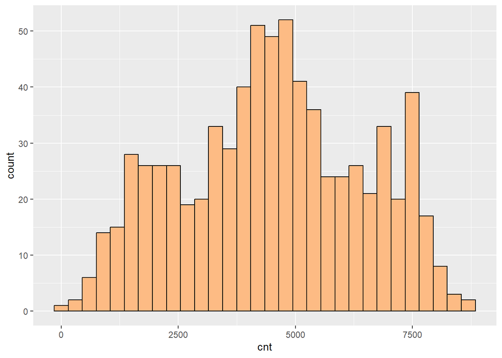

```r
data %>%
  ggplot(aes(x = cnt)) + geom_histogram(fill = "#fdbb84", color = "black")
```

The response in this case is a count of bicycles rented for the day. Count data is most often represented by a poisson or negative/positive binomial distribution. The difference between these 2 distributions is that poisson regression is used for count where the mean is roughly equal to the standard deviation. We check to see whether this holds for the bikeshare data.

```r
data$cnt %>% sd()
```

```
## [1] 1937.211
```

```r
data$cnt %>% mean()
```

```
## [1] 4504.349
```

The mean and standard deviation in the sample suggest rather larger overdispersion. Which may indicate that a quasi-poison or negative binomial distribution will be better performing then a poisson distribution on this data.

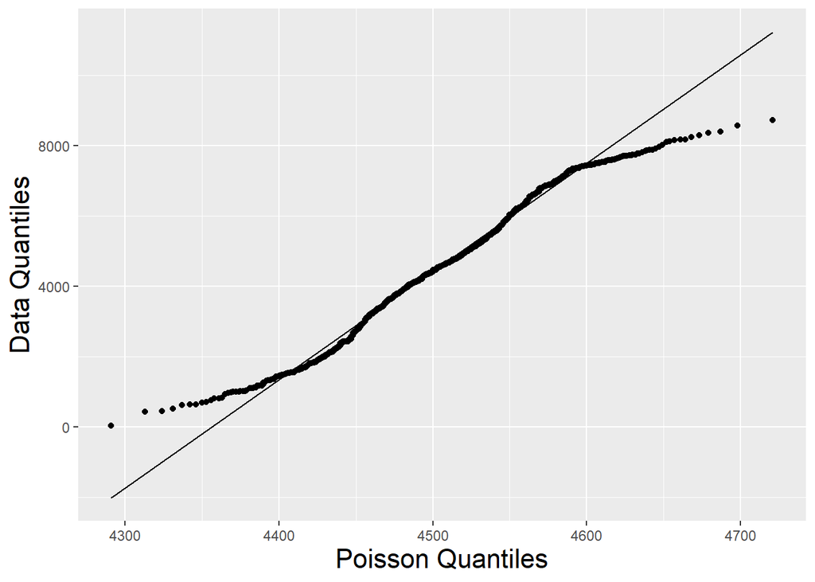

```r
data %>%
  ggplot(aes(sample = cnt))+stat_qq(distribution = stats::qpois, dparams = list(lambda = mean(data$cnt)))+ stat_qq_line(distribution = stats::qpois, dparams = list(lambda = mean(data$cnt))) +
  ylab("Data Quantiles") +
  xlab("Poisson Quantiles") +
  theme(axis.title.y = element_text(size = rel(1.5), angle = 90)) +
  theme(axis.title.x = element_text(size = rel(1.5), angle = 00))
```

Now lets look at how some of our predictors relate to the number of bikes rented.

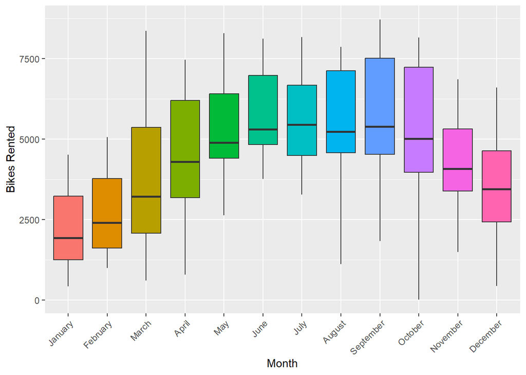

```r
data %>%
  mutate(month = fct_reorder(as.factor(month.name[mnth]), mnth)) %>%
  ggplot(aes(x = month, fill = month, y = cnt))+geom_boxplot() +
  xlab("Month") +
  ylab("Bikes Rented") +
  theme(legend.pos = 'none')+
  theme(axis.text.x = element_text(angle = 45, vjust = 1, hjust=1))
```

As we may expect bike rentals peak in the warmer summer months and decline during colder winter months before picking back up again as the seasons change. It will be important we capture the cyclical nature of this strong predictor for the bike rentals in our model.

Similarly we visualize the days of the week

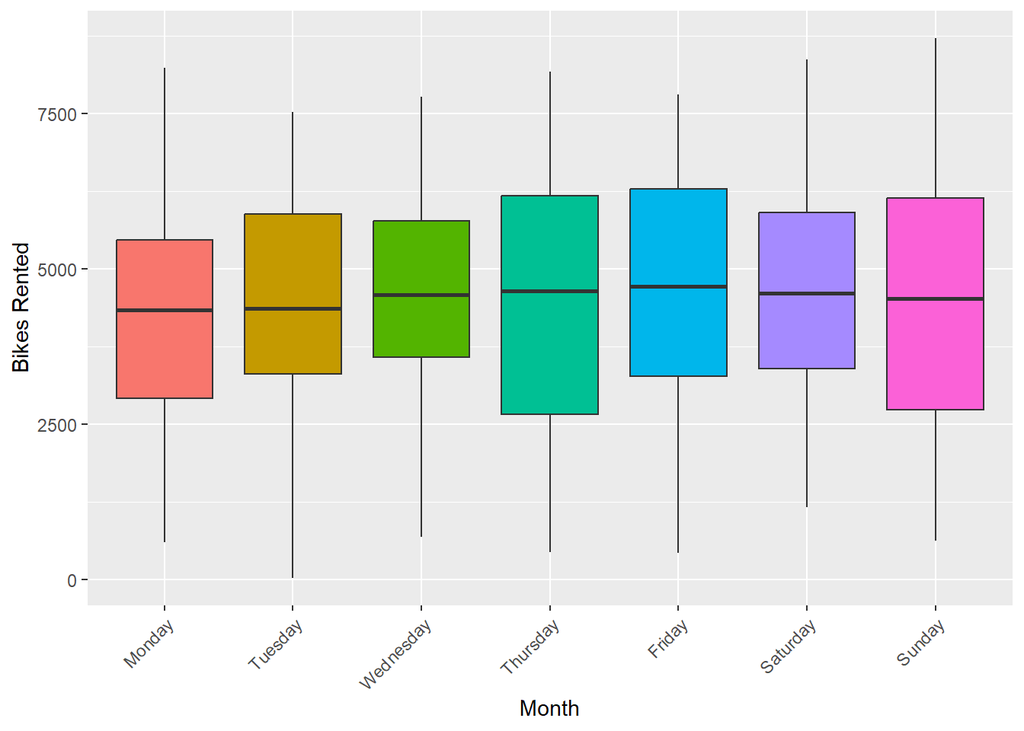

```r
df.1 <- data
df.1$weekday <- factor(df.1$weekday, levels=0:6,
                      labels=c("Monday", "Tuesday", "Wednesday",
                               "Thursday", "Friday", "Saturday", "Sunday"))
df.1 %>%
  ggplot(aes(x = weekday, fill = weekday, y = cnt))+geom_boxplot() +
  xlab("Month") +
  ylab("Bikes Rented") +
  theme(legend.pos = 'none')+
  theme(axis.text.x = element_text(angle = 45, vjust = 1, hjust=1))
```

We don’t see any particular day being significantly more popular for renting a bike then the others. We can get a precise look at that count:

```r
df.1 %>%
  group_by(weekday) %>%
  summarize(n = sum(cnt))
```

| weekday | n |
| --- | --- |
| Monday | 444027 |
| Tuesday | 455503 |
| Wednesday | 469109 |
| Thursday | 473048 |
| Friday | 485395 |
| Saturday | 487790 |
| Sunday | 477807 |

We can again take a closer look just by comparing working and non working days.

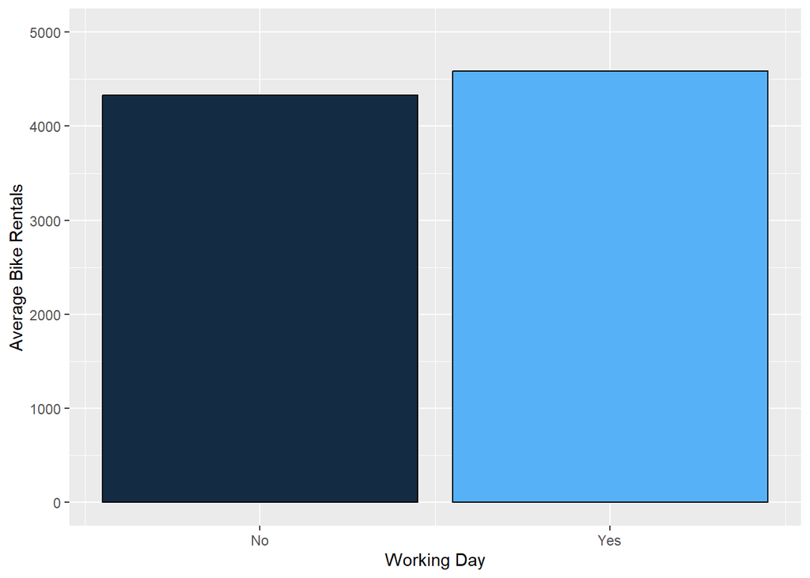

```r
data %>%
  dplyr::select(cnt, workingday) %>%
  group_by(workingday) %>%
  summarize(counts = mean(cnt)) %>%
  ungroup() %>%
  ggplot(aes(x = workingday, y = counts, fill = workingday))+geom_bar(stat = "identity", color = "black") +
  theme(legend.position = "none") +
  ylab("Average Bike Rentals") +
  xlab("Working Day") +
  scale_y_continuous(limits = c(0,5000)) +
  scale_x_continuous(breaks = c(0,1), labels = c("No", "Yes"))
```

We see little difference in the average rentals on working days as non working days. This suggests that this predictor will not be a strong indicator in our model for predicting the number of bikes rented.

We now visualize some of the continuous variables present in the data and their relationship with rental counts.

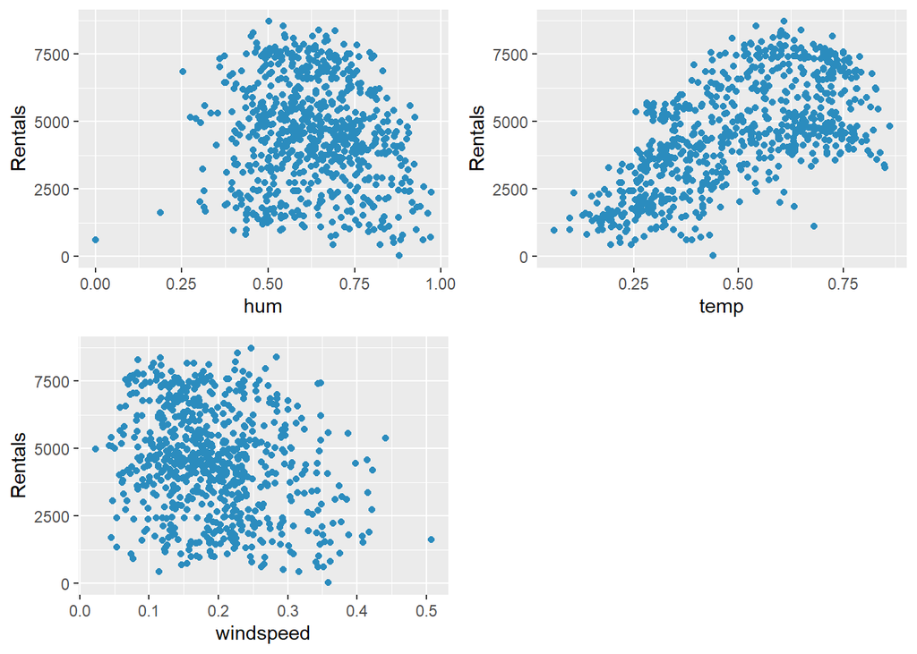

```r
ggplot_helper <- function(data, x){
  ggplot(data = data, aes(x = {{x}}, y = cnt)) + geom_point(color = "#2b8cbe")+
  ylab("Rentals")
}

plot_grid(ggplot_helper(data, x = hum), ggplot_helper(data, temp),ggplot_helper(data, windspeed), labels = "")
```

Though the relationship between temp and rental count seems almost linear, it is clear that we may have some non linear relationships present in these predictors.

# Model Building

First we can try fitting both a linnear regression and poisson regression model. We make slight adjustments to the features to ensure dates are encoded as datetime objects and remove variables like instant which just refer to the observation number, we also remove registered and casual since these variables are just leakage of the counts into the predictors. Then compute the mean square errors on the test data.

```r
# Convert date to Date type
data$date <- as.Date(data$dteday)

# Remove unnecessary columns
data <- data %>% dplyr::select(-instant, -dteday, -casual, -registered)

# Split the data into training and testing sets for glmnet()
set.seed(1)
train_indices <- sample(1:nrow(data), size = 0.8 * nrow(data))
train_data <- data[train_indices,]
test_data <- data[-train_indices,]
```

```r
set.seed(1)

# Fit poisson regression model
glm.fit <- glm(cnt ~ ., data = data,
                 family = poisson())

lm.fit <- glm(cnt ~., data = data)

# Initialize a vector to store 10 fold CV errors
cv.error.10 <- rep(0,10)

# Perform 10-fold CV and store errors
for (i in 1:10) {
  cv.error.10[i] <- cv.glm(data, glm.fit, K = 10)$delta[1]
}

#Compute and report 10 fold CV-error
cat("Root Mean Squared Error (RMSE) for LOOCV:", sqrt(mean(cv.error.10)), "\n")
```

```
## Root Mean Squared Error (RMSE) for LOOCV: 1017.788
```

```r
# Compute LOOCV
cv.err <- cv.glm(data, glm.fit)
cat("Root Mean Squared Error (RMSE) for LOOCV:", sqrt(cv.err$delta[1]), "\n")
```

```
## Root Mean Squared Error (RMSE) for LOOCV: 1015.631
```

```r
cv.err_lm <- cv.glm(data, lm.fit)
cat("Root Mean Squared Error of LM (RMSE) for LOOCV:", sqrt(cv.err_lm$delta[1]), "\n")
```

```
## Root Mean Squared Error of LM (RMSE) for LOOCV: 888.1215
```

We will only compute the LOOCV RMSE from here on since the model is not particularly large and so LOOCV computes relatively quickly.

Currently we see the linear regression model actually outperforming the poisson regression, which should suggest a problem as our count data naturally is better suited to the poisson distriubtion. We will do some additional feature engineering. We will encode the datetime as a cyclical variable using sine and cosine functions. This will establish that for instance January is closer to December then it is to April.

```r
#cyclical encoding of mnth, weekday
data$mnth_sin <- sin(2 * pi * data$mnth / 12)
data$mnth_cos <- cos(2 * pi * data$mnth / 12)

data$weekday_sin <- sin(2 * pi * data$weekday / 7)
data$weekday_cos <- cos(2 * pi * data$weekday / 7)

train_data <- data[train_indices,]
test_data <- data[-train_indices,]
```

We also have some interactions among these predictors, for example the combination of cold temperatures and rain/snow is probably less desirable then just a cold or just a rainy day for riding a bike. We’ll also add non linear terms for the continuous variables such as temperature, humidity, and windspeed.

```r
set.seed(1)
# Fit Poisson regression model
model <- glm(cnt ~ . + weathersit*temp, data = data, family = poisson())

lm.fit <- glm(cnt ~ . + weathersit*temp, data = data)

# Compute LOOCV
cv.err <- cv.glm(data, model)
cat("Root Mean Squared Error (RMSE) for LOOCV:", sqrt(cv.err$delta[1]), "\n")
```

```
## Root Mean Squared Error (RMSE) for LOOCV: 963.5958
```

```r
cv.err_lm <- cv.glm(data, lm.fit)
cat("Root Mean Squared Error of LM (RMSE) for LOOCV:", sqrt(cv.err_lm$delta[1]), "\n")
```

```
## Root Mean Squared Error of LM (RMSE) for LOOCV: 871.8762
```

We get a slight decrease in the square error in the test. We now will try analyzing the residuals to see if there are some higher order relationships that the model does not currently capture.

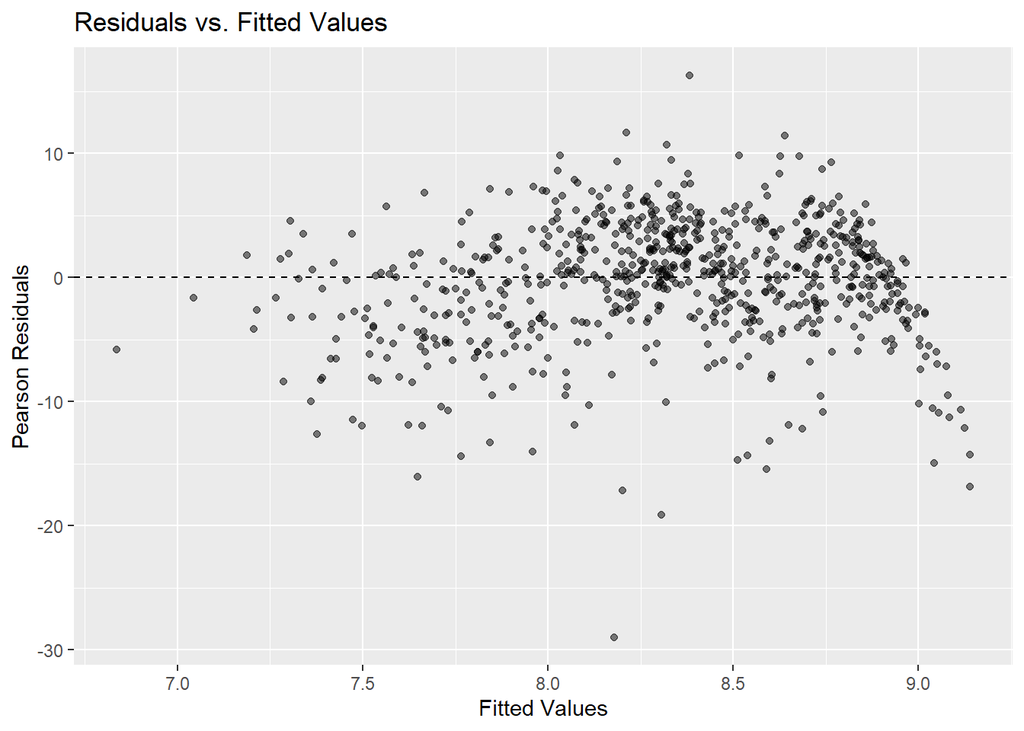

```r
# Creating a dataframe containing residuals and fitted values
df <- broom::augment(model)

# Residuals vs. fitted values plot
ggplot(df, aes(x = .fitted, y = .resid/sqrt(.fitted))) +
  geom_point(alpha = 0.5) +
  geom_hline(yintercept = 0, linetype = "dashed") +
  labs(title = "Residuals vs. Fitted Values", x = "Fitted Values", y = "Pearson Residuals")
```

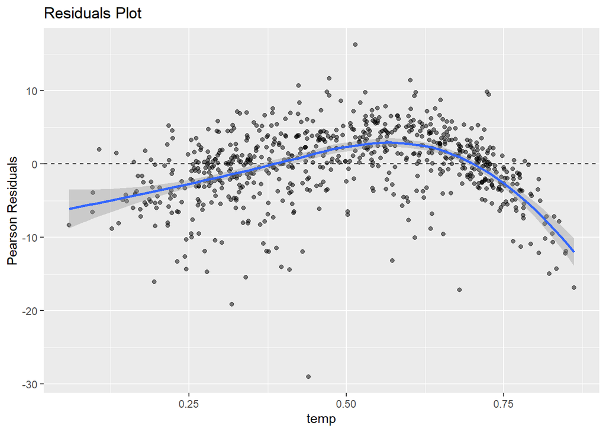

```r
# Residuals vs. continuous predictors fucntion helper
resid.check <- function(data, x, y) {
  ggplot(data, aes(x = {{x}}, y = {{y}})) +
    geom_point(alpha = 0.5) +
    geom_hline(yintercept = 0, linetype = "dashed") +
    labs(title = "Residuals Plot", y = "Pearson Residuals") +
    geom_smooth()
}
resid.check(df, temp, y = .resid/sqrt(.fitted))
```

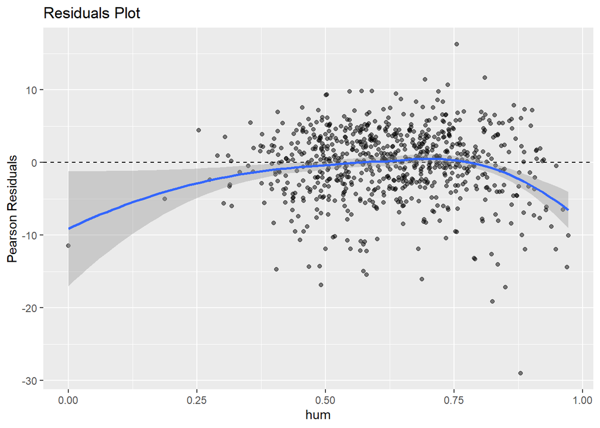

```r
resid.check(df, x = hum, y = .resid/sqrt(.fitted))
```

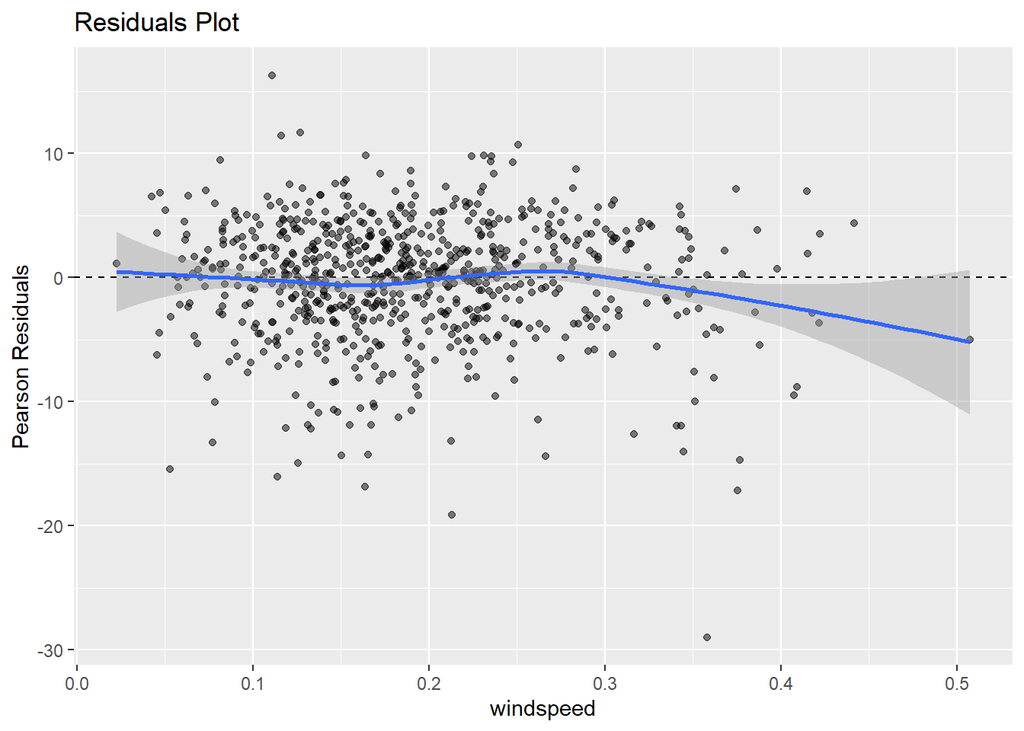

```r
resid.check(df, x = windspeed, y = .resid/sqrt(.fitted))
```

We check our continuous predictors and find a definite pattern within the temp predictor and the hum predictor, suggesting there is a relationship not being captured by the model.

We can adjust for this by adding non linear transformations of temp and hum.

```r
# Fit Poisson regression model
model <- glm(cnt ~ . - temp + weathersit*temp + poly(temp,3) - hum + poly(hum,4), data = data, family = poisson())

lm.fit <- glm(cnt ~ . - temp + weathersit*temp + poly(temp,3) - hum + poly(hum,4), data = data)

# Compute LOOCV
cv.err <- cv.glm(data, model)
cat("Root Mean Squared Error (RMSE) for LOOCV:", sqrt(cv.err$delta[1]), "\n")
```

```
## Root Mean Squared Error (RMSE) for LOOCV: 664.7799
```

```r
cv.err_lm <- cv.glm(data, lm.fit)
cat("Root Mean Squared Error of LM (RMSE) for LOOCV:", sqrt(cv.err_lm$delta[1]), "\n")
```

```
## Root Mean Squared Error of LM (RMSE) for LOOCV: 674.6041
```

We see significant reductions in RMSE for both models however the particularly in the poisson model which now performs slightly better then the linear regression model as we had expected. We can check the residual plots again with this new model.

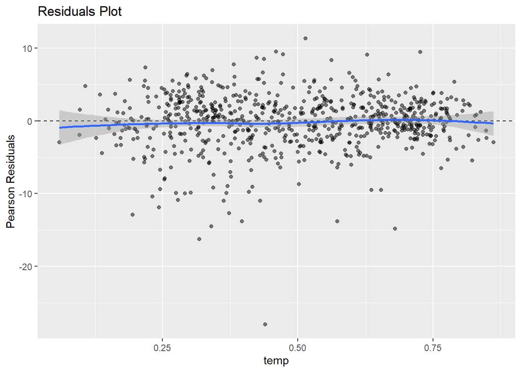

```r
#Checking residual values after adjusting model for nonlinear values

df <- broom::augment(model)

resid.check(df, x = temp, y = .resid/sqrt(.fitted))
```

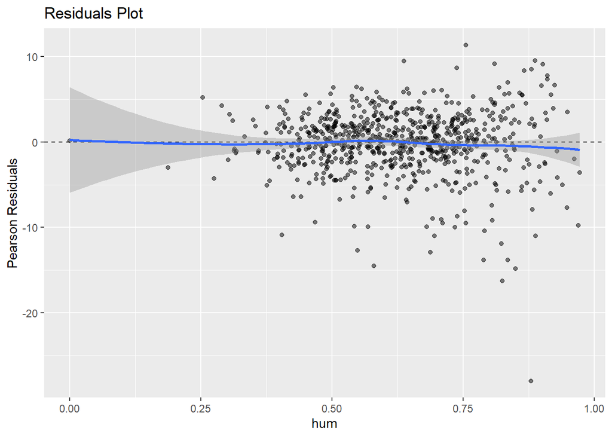

```r
resid.check(df, x = hum, y = .resid/sqrt(.fitted))
```

Now we get a much more randomly scattered plot of the residuals after the transformations. We can add these additional predictors directly into the dataset.

```r
#Creating polynomial terms for temp
data <- data %>% dplyr::mutate(temp_2 = temp^2, temp_3 = temp^3)

#Creating polynomial terms for hum
data <- data %>% dplyr::mutate(hum_2 = hum^2, hum_3 = hum^3, hum_4 = hum^4)

#Adding to train-test splits
train_data <- data[train_indices,]
test_data <- data[-train_indices,]
```

We now refit the model.

```r
# Fit Poisson regression model
model <- glm(cnt ~ . - temp + weathersit*temp, data = data, family = poisson())

# Compute LOOCV
cv.err <- cv.glm(data, model)
cat("Root Mean Squared Error (RMSE) for LOOCV:", sqrt(cv.err$delta[1]), "\n")
```

```
## Root Mean Squared Error (RMSE) for LOOCV: 664.7799
```

We may try lasso regression as a method for variable selection. If dimension reduction would improve this model we should see this method reduce RMSE. However due to the overall size of this model still being relatively small relative to the sample size it’s unlikely to be the case.

```r
#Create model matrix
set.seed(1)
X <- model.matrix(cnt ~ . -1, data = train_data)
X.test <- model.matrix(cnt ~ . -1, data = test_data)
Y <- train_data$cnt
Y.test <- test_data$cnt
# Fit LASSO model
lasso <- glmnet(X, Y, family = "poisson" , alpha = 1)
# Cross Validating lambda values
lasso.cv <- cv.glmnet(X, Y, family = "poisson", alpha = 1)
# Finding optimal lambda
optimal <- lasso.cv$lambda.min
# Fit the optimal lambda model
lasso.mod <- glmnet(X, Y, family = "poisson", alpha = 1, lambda = optimal)

# Make predictions
lasso.pred <- predict(lasso, optimal, newx = X.test)

cat("Root Mean Squared Error (RMSE) for LOOCV:", sqrt(mean((lasso.pred-Y.test)^2)), "\n")
```

```
## Root Mean Squared Error (RMSE) for LOOCV: 4838.631
```

We now may select some other models to test against the poisson regression. Of particular interest should be negative binomial regression and quasi poisson regression, since we observed evidence of overdispersion.

```r
set.seed(1)

# Fit poisson regression model
glm.fit <- glm.nb(cnt ~ .  + weathersit*temp, data = data)


# Compute LOOCV
cv.err <- cv.glm(data, glm.fit)
cat("Root Mean Squared Error (RMSE) for LOOCV:", sqrt(cv.err$delta[1]), "\n")
```

```
## Root Mean Squared Error (RMSE) for LOOCV: 696.4179
```

We see that the negative binomial model slightly underperforms the already fitted poisson model. We may seek further improvements through highly non linear methods such as gradient boosting.

```r
set.seed(1)

gbm_model <- gbm(cnt ~ .-date,data = train_data ,  distribution = "gaussian",
                 n.trees = 1000,
                 interaction.depth = 3,
                 shrinkage = 0.01,
                 n.minobsinnode = 10,
                 cv.folds = 10,
                 verbose = FALSE)
optimal_trees <- gbm.perf(gbm_model, method = "cv")
```

[figure not shown]

```r
predictions_1 <- predict(gbm_model, newdata = test_data, n.trees = optimal_trees)
performance <- postResample(predictions_1, test_data$cnt)
print(performance)
```

```
##        RMSE    Rsquared         MAE
## 625.5537626   0.9035997 465.0759874
```

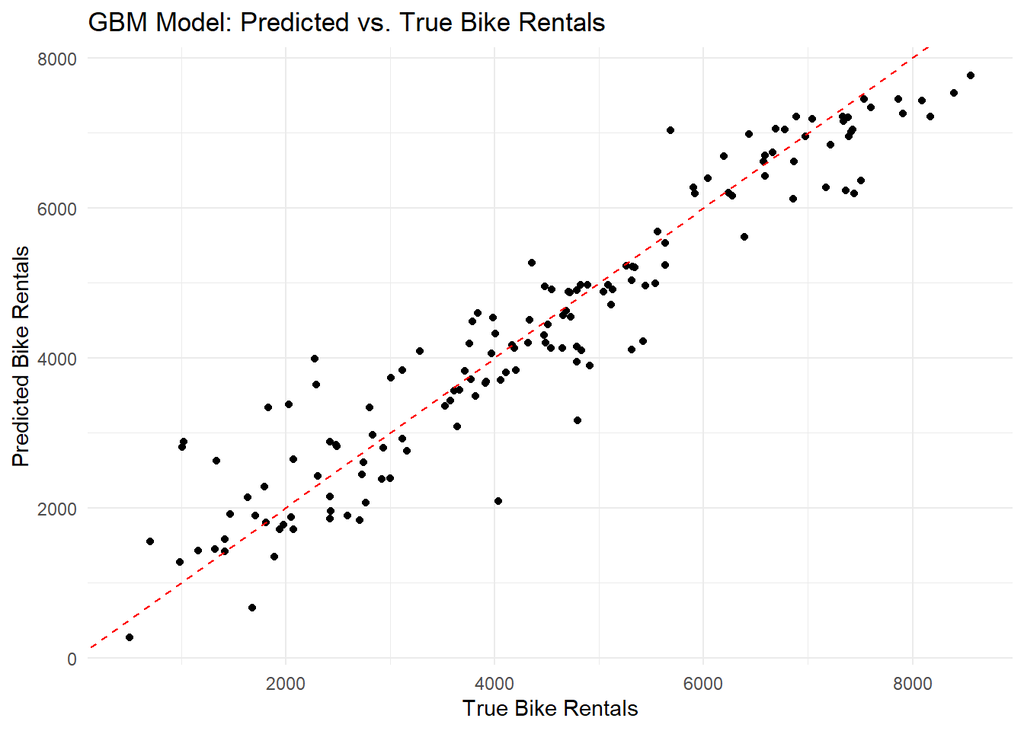

```r
library(ggplot2)

pred_vs_true <- data.frame(Predicted = predictions_1, True = test_data$cnt)
ggplot(pred_vs_true, aes(x = True, y = Predicted)) +
  geom_point() +
  geom_abline(intercept = 0, slope = 1, color = "red", linetype = "dashed") +
  labs(title = "GBM Model: Predicted vs. True Bike Rentals",
       x = "True Bike Rentals",
       y = "Predicted Bike Rentals") +
  theme_minimal()
```

We find the gradient boosting method to perform the best of our models so far, we can continue applying SVM and randomForest

```r
set.seed(1)
# Normalizing train and test split
preprocess_params <- preProcess(train_data[, -which(names(train_data) == "cnt")], method = c("center", "scale"))

train_data_scaled <- predict(preprocess_params, train_data)
test_data_scaled <- predict(preprocess_params, test_data)
test_data_scaled$cnt <- test_data$cnt

# Training model with svm()
svm_model <- svm(cnt ~ .,
                 data = train_data_scaled,
                 kernel = "radial",
                 cost = 1,
                 gamma = 0.1,
                 epsilon = 0.1)

# Computing error rates
predictions <- predict(svm_model, newdata = test_data_scaled)
performance <- postResample(predictions, test_data_scaled$cnt)
print(performance)
```

```
##        RMSE    Rsquared         MAE
## 703.1824313   0.8772213 476.1026933
```

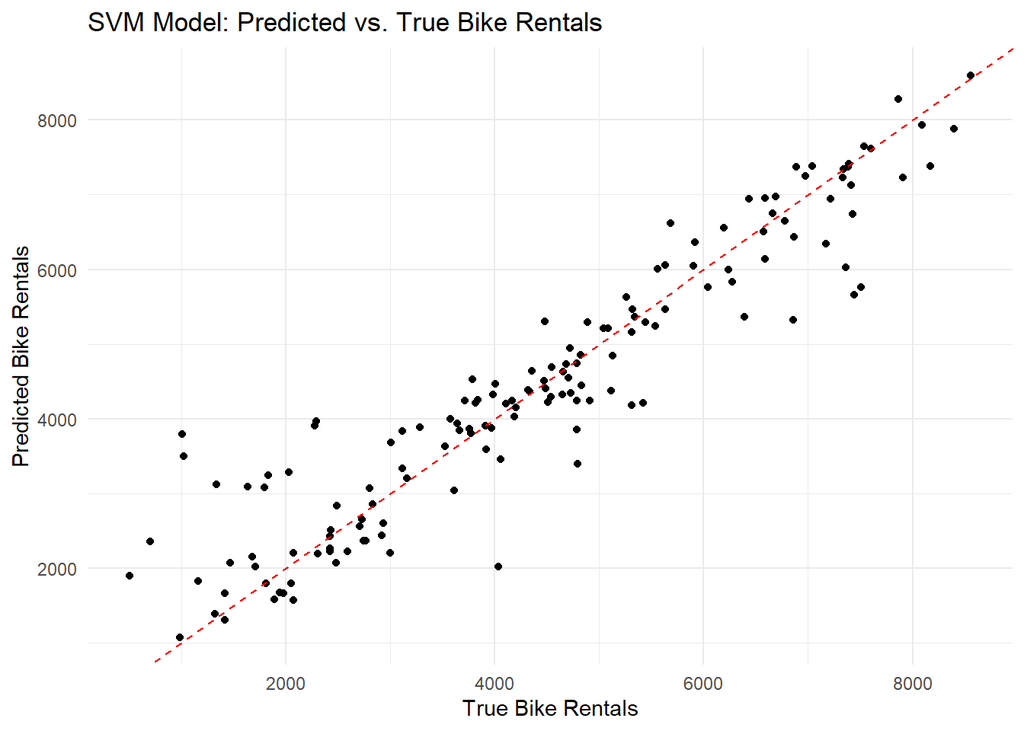

```r
library(ggplot2)

pred_vs_true <- data.frame(Predicted = predictions, True = test_data_scaled$cnt)
ggplot(pred_vs_true, aes(x = True, y = Predicted)) +
  geom_point() +
  geom_abline(intercept = 0, slope = 1, color = "red", linetype = "dashed") +
  labs(title = "SVM Model: Predicted vs. True Bike Rentals",
       x = "True Bike Rentals",
       y = "Predicted Bike Rentals") +
  theme_minimal()
```

Now we use the random forest method

```r
set.seed(1)

# Defining Control Parameters
control_rfe <- rfeControl(functions = rfFuncs,
                          method = "cv",
                          number = 5,
                          verbose = FALSE)

# Defining Predictors
predictors <- names(train_data[, !(names(train_data) %in% c("cnt"))])

# Run RFE
rfe_result <- rfe(train_data[, predictors],
                  train_data$cnt,
                  sizes = c(1:10),
                  rfeControl = control_rfe)
print(rfe_result)
```

```
##
## Recursive feature selection
##
## Outer resampling method: Cross-Validated (5 fold)
##
## Resampling performance over subset size:
##
##  Variables   RMSE Rsquared   MAE RMSESD RsquaredSD  MAESD Selected
##          1  943.1   0.7647 674.9  68.53    0.04260  37.57
##          2 1031.1   0.7187 772.3 126.25    0.06313 110.21
##          3  950.9   0.7640 707.8  42.59    0.03322  58.98
##          4  966.6   0.7647 735.5  64.43    0.02390  58.21
##          5  921.6   0.7861 694.7  93.44    0.05464  64.57
##          6  784.6   0.8361 553.2  60.90    0.02196  27.18
##          7  794.1   0.8326 558.9  58.02    0.01950  29.68
##          8  778.5   0.8388 544.3  72.95    0.02640  45.46
##          9  765.6   0.8439 534.5  62.21    0.02045  32.64
##         10  763.4   0.8447 534.1  59.24    0.01831  33.01
##         21  716.1   0.8637 489.0  57.50    0.01691  31.41        *
##
## The top 5 variables (out of 21):
##    date, yr, season, atemp, hum_2
```

```r
best_features <- predictors[rfe_result$optVariables]

# Train the final model with the selected features
model <- randomForest(cnt ~ ., data = train_data[, c("cnt", rfe_result$optVariables)])

# Evaluate the model performance on the test dataset
predictions_2 <- predict(model, newdata = test_data[, rfe_result$optVariables])
performance <- postResample(predictions, test_data$cnt)
print(performance)
```

```
##        RMSE    Rsquared         MAE
## 703.1824313   0.8772213 476.1026933
```

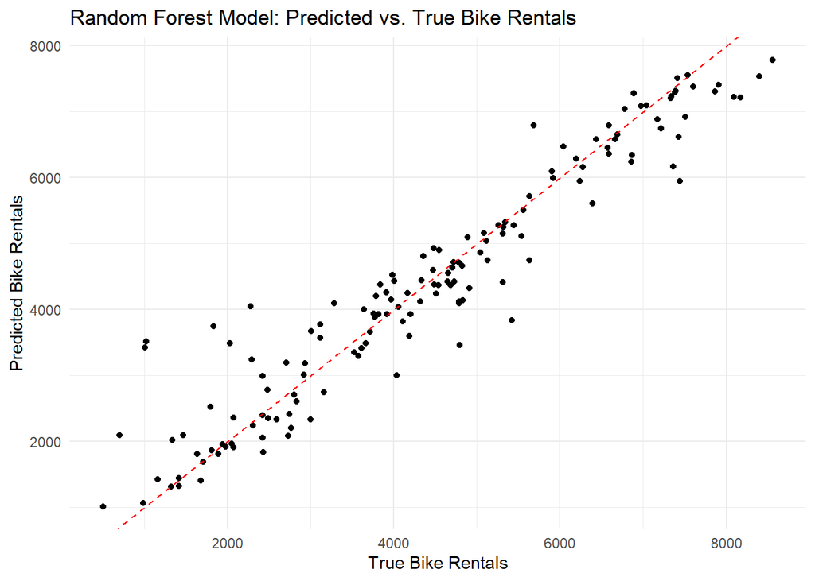

```r
library(ggplot2)

pred_vs_true <- data.frame(Predicted = predictions_2, True = test_data$cnt)
ggplot(pred_vs_true, aes(x = True, y = Predicted)) +
  geom_point() +
  geom_abline(intercept = 0, slope = 1, color = "red", linetype = "dashed") +
  labs(title = "Random Forest Model: Predicted vs. True Bike Rentals",
       x = "True Bike Rentals",
       y = "Predicted Bike Rentals") +
  theme_minimal()
```

Both the SVM and random forest fail to outperform the poisson regression model. And since these models are less interpretable and take longer to train it’s clear they are poor choices.

The GBM model however performs better then the poisson method and appears to be the best performing method of prediction overall.